# Applied Case Study: Progressive Disease Model

Replicating and Extending Green et al. (2023)

# Introduction

The objective of this case study is to replicate and extend the model and results in Green et al. (2023) using tools developed in this workshop.

Green et al. (2023) provide a [link to the Excel file](https://github.com/Excel-R-tutorials/Markov-model-introduction/blob/ea65640a064d9d01f56295cbbab90ab4865c38fc/original_Excel_files/Media_343196_smxx.xlsm) as well as [code to execute the same model in R](https://github.com/Excel-R-tutorials/Markov-model-introduction/blob/main/Markov_model_realworld.R). The R code is written in base R, meaning that it does not require any loaded packages to execute. However, the model structure is somewhat complicated—requiring, for example, both state occupancy and transitions out of certain states to be tracked.

Specifically, in the Green et al. (2023) model there is an additional cost from transitioning from Progressive disease to death, but this cost does not apply if the cause of death was background mortality.

The model is structured as follows:

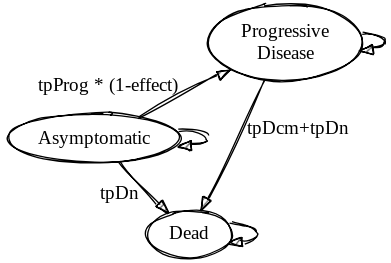

Created on Sketchviz

In this model, individuals begin in an `Asymptomatic` disease state and are at risk of transitioning to a `Progressive Disease` state in a given cycle with probability `tpProg`. Individuals can also progress to a death state based on background causes (`tpDn`) or due to a heightened risk of death due to progressive disease (`tpDcm`).

The model considers the costs and benefits of two strategies:

1. **Without Drug:** a base case in which individuals incur a cost of Asymptomatic disease ($500/year), an (annual) $3,000 cost of progressive disease, and a one-time ($1,000) cost if they die from progressive disease. Utility payoffs are set at 0.95 in the Asymptomatic state, and 0.75 in the Progressive Disease State.
2. **With Drug**: a strategy in which a drug is available in the Asymptomatic state. This drug costs $1,000 per year and lowers the probability of entering the Progressive Disease state by 50%. All other costs and utilities are the same as in the **No Drug** strategy.

The code provided below replicates the original model, but draws on various capabilities within the (now ubiquitous) `tidyverse` universe to both simplify and generalize the execution process.

We will consider model replication through two methods:

#### A. Using the supplied transition probabilities as marginal (total) probabilities.

This approach will embed a transition rate matrix after converting the supplied (annual) probabilities into rates.

#### B. Using Higham (2008)

This approach will begin from a transition probability matrix as constructed using the supplied transition probabilities. We’ll then calculate the principal logarithm of the matrix based on the methods in Higham (2008) and use the [resulting intensity (generator) matrix](https://www.maths.manchester.ac.uk/~higham/talks/napier_log14.pdf) as the basis for the final transition probability matrix.

# 0. Set Up and Parameterize the Model

We first load up all necessary packages and define functions for cycle adjustments based on [Simpson’s Rule](https://en.wikipedia.org/wiki/Simpson%27s_rule).

```r
library(tidyverse)
library(demography)
library(MortalityLaws) # devtools::install_github("mpascariu/MortalityLaws")
library(directlabels)
library(ggsci)
library(hrbrthemes)
library(MASS)
library(mgcv)
library(patchwork)
library(knitr)
library(kableExtra)
library(here)
library(ggsci)
library(expm)
library(glue)
select =dplyr::select
options("scipen" = 100, "digits" = 5)

# Cycle adjustment function
alt_simp_coef =function(i) c(17, 59, 43, 49, rep(48, i-8), 49, 43, 59, 17) / 48
cycle_adj      =function(x) sum(alt_simp_coef(length(x)) * x)
```

## Parameterize

We next parameterize the model. The `params` list object below replicates the parameters in Green et al. (2023).

```r
params = list(
    t_names = c("without_drug", "with_drug"),      # Treatment names
    n_treatments =2,                               # Number of treatments

    s_names  = c("Asympt", "Progressive", "Dead"), # State names
    n_states = 3,                                  # Number of states

    n_cohort =1000,                                # Cohort size
    cycle_length = 1,                              # Cycle length
    time_horizon = 45,                             # Model time horizon (in years)
    initial_age = 55,                              # Cohort starting age
    effect = 0.5,                                  # Treatment Effect (drug)

    cAsymp =500,                                   # Cost of asympomatic state
    cDeath =1000,                                  # cost of death (progressive disease state only)
    cDrug =1000,                                   # Cost of drug
    cProg =3000,                                   # Cycle cost of progressive disease

    uAsymp =0.95,                                  # Asymptomatic state utility
    uProg =0.75,                                   # Progressive disease state utility

    oDr = 0.0,                                    # Discount rate (QALYs)
    cDr = 0.0,                                    # Discount rate (costs)

    tpDcm =0.15,                                   # Death from progressive disease trans prob
    tpProg =0.01,                                  # Transition prob: progressive disease
    tpDn =0.0379                                   # Background mortality transition prob
)
```

To retain flexibility to change the model time step (e.g., annual, monthly, daily) we next add and re-define some parameters that are functions of other parameters. For example:

- `n_cycles` should be flexibly adapted so that it can respond if we set a different cycle length while keeping the simulation time horizon the same.
- Similarly, the defined (annual) discounting rates also must be adapted for shorter vs. longer cycle lengths.

These changes will become important later when we check how robust our results are to shortening the cycle length.

```r
params =
    modifyList(params, with(params, {
        list(
            n_cycles = time_horizon / cycle_length,
            oDr = ((1 + oDr)^(cycle_length) - 1),
            cDr = ((1 + cDr)^(cycle_length) - 1)
        )
    }))
```

# A. Construct the Model Using Rate Conversion

The first approach we will consider will take the supplied transition probabilities (i.e., parameters with the `tp` prefix) and convert them to rates. Note that by doing so, we are making an assumption that there are no competing events operating on the transition probabilities (see Lecture 2).

Once we have converted to continuous rates, we will then re-embed the transition probability matrix so that it will capture compound transitions across three or more states in a cycle.

## A1. Markovian Transition Rate Matrix

Our first step is to fill out the Markovian rate matrix. This matrix should be square with `n_states`=3 rows and columns.

To run our model, we must construct a separate transition matrix for every cycle. This is because several transition probabilities are a function of age:

- Background mortality is based on the following lookup table of death probabilities by age group:

```r
 tpDn_lookup <-
        c(
          "(34,44]" = 0.0017,
          "(44,54]" = 0.0044,
          "(54,64]" = 0.0138,
          "(64,74]" = 0.0379,
          "(74,84]" = 0.0912,
          "(84,100]" = 0.1958
        )
tpDn_lookup %>%
  data.frame() %>%
  kable(col.names = c("Probability of Death")) %>%
  kable_styling(full_width = FALSE)
```

|  | Probability of Death |
| --- | --- |
| (34,44] | 0.0017 |
| (44,54] | 0.0044 |
| (54,64] | 0.0138 |
| (64,74] | 0.0379 |
| (74,84] | 0.0912 |
| (84,100] | 0.1958 |

- The probability of disease progression increases by 0.01 per year.

To incorporate these dynamics, we’ll define a function that takes as its inputs a vector of cycles (`t`) as well as the parameter list object defined above.

We’ll begin with an annual time step, so the cycle vector `t` should be defined as 1:45, since we’re working over a 45 year time horizon.

```r
t = 1:45
```

We next need to iterate over each of these cycles and define a rate matrix specific to that cycle. Each iteration will be indexed by `tt`.

To demonstrate how to construct the rate matrix for the first cycle, let’s set `tt` to 1.

```r
tt = 1
```

At `tt` = 1, we need to figure out the current age of the cohort at the end of the cycle. This is useful to extract the correct death transition probability.

```r
current_age = with(params, initial_age + cycle_length * tt)
current_age
```

```
[1] 56
```

We next find the death probability from the lookup table based on age at the begnning of the cycle. We also convert this probability to a rate.

```r
age_grp = with(params,cut(current_age - tt * cycle_length, breaks = c(34,44,54,64,74,84,100)))
tpDn = tpDn_lookup[age_grp]
tpDn
```

```
(54,64]
 0.0138
```

```r
rDn = -log(1 - tpDn)
rDn
```

```
 (54,64]
0.013896
```

We also must calculate the probability of transitioning to progressive disease, which in the original model increases by 0.01 per year.

```r
year = with(params, tt * cycle_length)
tpProg_ = with(params, tpProg * ceiling(year))
tpProg_
```

```
[1] 0.01
```

The original model also specifies several other marginal transition probabilities. We’ll next convert each of these to rates:

```r
rProg = with(params,-log(1 - tpProg_))
rProgDrug = with(params,-log(1 - (tpProg_ * (1 - effect))))
rDcm = with(params,-log(1 - tpDcm))
```

We can now collect all of these rates within rate matrices—one matrix for each strategy.

Note that to fill in a matrix you must go column by column. Therefore, the code here specifies each column in each row.

```r
mR_ =
    with(params,{
      array(data = c(
                   0, 0, 0,
                   rProg, 0, 0,
                   rDn, rDn + rDcm, 0,

                   0, 0, 0,
                   rProgDrug, 0, 0,
                   rDn, rDn + rDcm, 0, 0),

                  dim = c(n_states, n_states, n_treatments),
                  dimnames = list(from = s_names,
                                  to = s_names,
                                  t_names))
    })
mR_
```

```
, ,  = without_drug

             to
from          Asympt Progressive     Dead
  Asympt           0     0.01005 0.013896
  Progressive      0     0.00000 0.176415
  Dead             0     0.00000 0.000000

, ,  = with_drug

             to
from          Asympt Progressive     Dead
  Asympt           0   0.0050125 0.013896
  Progressive      0   0.0000000 0.176415
  Dead             0   0.0000000 0.000000
```

Our final step is to balance out the rate matrix in the diagonals. The diagonal elements are simply the negative row sum of the off-diagonal elements:

```r
mR = apply(mR_,3,function(x){
            diag(x) = -rowSums(x)
            x
        },simplify=FALSE)
mR
```

```
$without_drug
             to
from             Asympt Progressive     Dead
  Asympt      -0.023946     0.01005 0.013896
  Progressive  0.000000    -0.17642 0.176415
  Dead         0.000000     0.00000 0.000000

$with_drug
             to
from             Asympt Progressive     Dead
  Asympt      -0.018909   0.0050125 0.013896
  Progressive  0.000000  -0.1764150 0.176415
  Dead         0.000000   0.0000000 0.000000
```

We now have a transition rate matrix constructed for the first cycle! Our next step is to repeat this process for every cycle. The function below generalizes the above process and returns a list object with a different transition rate matrix for each cycle and strategy.

```r
fn_mRt_markov =function(t, params) {
  with(params, {
    lapply(t, function(tt) {

      current_age =initial_age + cycle_length * tt
      year = tt * cycle_length

      # Get background mortality rate
      tpDn_lookup <-
        c(
          "(34,44]" = 0.0017,
          "(44,54]" = 0.0044,
          "(54,64]" = 0.0138,
          "(64,74]" = 0.0379,
          "(74,84]" = 0.0912,
          "(84,100]" = 0.1958
        )
       age_grp =cut(current_age - tt * cycle_length, breaks = c(34,44,54,64,74,84,100))
       tpDn =tpDn_lookup[age_grp]

       tpProg_ = tpProg * ceiling(year)

       # Convert supplied probabilities back to rates.
       rProg = -log(1 - tpProg_)
       rProgDrug = -log(1-(tpProg_*(1-effect)))
       rDcm = -log(1 - tpDcm)
       rDn = -log(1 - tpDn)

       # Define off-diagonal elements of rate matrix
       mR_ =
            array(data = c(
                           0, 0, 0,
                           rProg, 0, 0,
                           rDn, rDn + rDcm, 0,

                           0, 0, 0,
                           rProgDrug, 0, 0,
                           rDn, rDn + rDcm, 0, 0),

                          dim = c(n_states, n_states, n_treatments),
                          dimnames = list(from = s_names,
                                          to = s_names,
                                          t_names))
       # Balance out rate matrix
       mR = apply(mR_,3,function(x){
            diag(x) = -rowSums(x)
            x
        },simplify=FALSE)

    })
  })
}
```

We see below that this recapitulates the same matrix we constructed by “hand” above:

```r
params$mRMarkov =
    fn_mRt_markov(1:params$n_cycles, params)
params$mRMarkov[[1]]
```

```
$without_drug
             to
from             Asympt Progressive     Dead
  Asympt      -0.023946     0.01005 0.013896
  Progressive  0.000000    -0.17642 0.176415
  Dead         0.000000     0.00000 0.000000

$with_drug
             to
from             Asympt Progressive     Dead
  Asympt      -0.018909   0.0050125 0.013896
  Progressive  0.000000  -0.1764150 0.176415
  Dead         0.000000   0.0000000 0.000000
```

## A2. Add Non-Markovian Components to Rate Matrix

Because transitions to death from the progressive disease state incur a one-time death cost of $1,000, we need to track the number of transitions to death in the model. We’ll do so by adding a non-Markovian transition state.

The basic procedure is to take the Markovian rate matrix defined above, and then add a transition state to the matrix. Note that the Markovian rate matrix is already balanced (i.e., the diagonal elements equal the negative row sum of off-diagonal elements). We will keep this part in tact and simply add a new column and row for the non-Markovian tracking state.

The function below takes as its input the parameter list object and the Markovian rate matrix (`R`) and adds in a new tracking state called `trDeadCause`. This tracker has a rate defined by the rate of transition from `Progressive Disease` to `Death`, i.e., `rDcm`.

```r
fn_mRt_nonmarkov = function(R,params) {
    R %>% map(~({  # Outer loop is over cycles in the model
        R_ = .x
        rDcm = -log(1 - params$tpDcm)
        lapply(R_,function(x) {  # Inner loop is over strategies
            x_ = cbind(x,"trDeadCause" = rep(0, params$n_states))
            x_ = rbind(x_,"trDeadCause" = rep(0,params$n_states+1))
            x_["Progressive","trDeadCause"] = rDcm
            x_
        })
    }))
}
```

We can see now that the transition rate matrix has been augmented to include a non-markovian transition state tracker:

```r
params$mR = fn_mRt_nonmarkov(R =params$mRMarkov,params)
params$mR[[1]]
```

```
$without_drug
               Asympt Progressive     Dead trDeadCause
Asympt      -0.023946     0.01005 0.013896     0.00000
Progressive  0.000000    -0.17642 0.176415     0.16252
Dead         0.000000     0.00000 0.000000     0.00000
trDeadCause  0.000000     0.00000 0.000000     0.00000

$with_drug
               Asympt Progressive     Dead trDeadCause
Asympt      -0.018909   0.0050125 0.013896     0.00000
Progressive  0.000000  -0.1764150 0.176415     0.16252
Dead         0.000000   0.0000000 0.000000     0.00000
trDeadCause  0.000000   0.0000000 0.000000     0.00000
```

## A3. Transition Probability Matrix

Our final step is to embed the transition probability matrix using matrix exponentiation.

We also have an added step of zeroing out the probability of transition from `trDeadCause` to `trDeadCause` because the model only counts the cost of death from Progressive Disease once, when the transition occurs. However, when we initially embed the matrix, this transition probability will be set to 1.0.

Recall that if we left this transition probability in tact at 1.0, our `trDeadCause` state would be an *accumulator* that counts the total number of transitions up to a given cycle, not the total number of transitions within that cycle.

```r
fn_mP = function(R, params) {
    with(params, {
        R %>% map( ~ ({
            lapply(.x, function(x) {
                tmp_ = expm(x * cycle_length)
                tmp_["trDeadCause", "trDeadCause"] = 0
                tmp_
            })
        }))
    })
}
```

You’ll see in the transition probability matrices for the first cycle below that the transition health state (`trDeadCause`) has a “jumpover” transition probability from the Asymptomatic state. This reflects the fact that there are some compound transitions within a cycle (i.e., transition from Asymptomatic to Progressive Disease to Death from Progressive Disease):

```r
params$mP =
    fn_mP(params$mR, params)
params$mP[[1]]
```

```
$without_drug
             Asympt Progressive     Dead trDeadCause
Asympt      0.97634   0.0091011 0.014561   0.0007645
Progressive 0.00000   0.8382700 0.161730   0.1489906
Dead        0.00000   0.0000000 1.000000   0.0000000
trDeadCause 0.00000   0.0000000 0.000000   0.0000000

$with_drug
             Asympt Progressive    Dead trDeadCause
Asympt      0.98127   0.0045509 0.01418  0.00038194
Progressive 0.00000   0.8382700 0.16173  0.14899063
Dead        0.00000   0.0000000 1.00000  0.00000000
trDeadCause 0.00000   0.0000000 0.00000  0.00000000
```

## A4. Markov Trace

With our cycle-specific transition probabilities constructed we can construct a full trace. We do so by defining a function `sim_cohort()` and feeding our parameter object into it:

```r
sim_cohort = function(params) {
    with(params,{
        t_names %>% map( ~ ({
            tr_ = # Create the initial trace
                t(c(n_cohort, rep(0, n_states)))

            res = # Iterate over the transition matrices (one for each cycle) and update
                   # the trace by binding on the next cycle's.
                do.call(rbind, lapply(mP, function(tp) {
                    tr_ <<- tr_ %*% matrix(unlist(tp[[.x]]), nrow = n_states + 1)
                }))

            res =# Add an initial state occupancy as the top row.
                rbind(c(n_cohort, rep(0, n_states)), res)

            res =# The current res object is a list; convert to a numeric matrix.
                matrix(unlist(res), ncol = n_states + 1)

            dimnames(res) = # Define the dimension names of
                             # the matrix (row = cycle, column = state)
                list(paste0(c(0:n_cycles)), colnames(mP[[1]][[1]]))
            res
    })) %>% # End result is a list object with one element for each strategy.
        set_names(t_names) # Name each of the strategies.
    })

}
```

Let’s now construct the trace

```r
trace = # Create the trace given the parameters.
    sim_cohort(params)
lapply(trace,head)
```

```
$without_drug
   Asympt Progressive   Dead trDeadCause
0 1000.00      0.0000  0.000      0.0000
1  976.34      9.1011 14.561      0.7645
2  943.61     25.3982 30.995      2.8513
3  902.67     47.0470 50.285      5.9554
4  854.60     72.2854 73.112      9.7837
5  800.67     99.4620 99.869     14.0584

$with_drug
   Asympt Progressive   Dead trDeadCause
0 1000.00      0.0000  0.000     0.00000
1  981.27      4.5509 14.180     0.38194
2  958.05     12.7455 29.204     1.42822
3  930.66     23.7622 45.581     2.99850
4  899.46     36.8568 63.686     4.96566
5  864.87     51.3568 83.774     7.21466
```

# B. Solving for the Generator Matrix

## B0. Parameterize the Model

Using a continuous generator in this example requires that we split out death from Progressive Disease and death from background causes. Why? Because there are two transition probabilities to death operating on individuals in the Progressive Disease state, and we need to find the underlying rates for each; if we bundled them together into a single transition probability, we’d have an identifiability issue—there are any number of combinations of rates that can yield the same (total) probability!

The adapted model diagram is provided below.

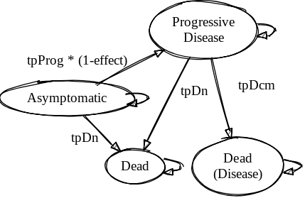

Hosted on Sketchviz

```r
paramsB <- modifyList(params,list(
    s_names  = c("Asympt", "Progressive", "DeadCause","Dead"), # State names
    n_states = 4                                              # Number of states
))
```

## B1. Markovian Rate Matrix

Mirroring step A1 above, let’s construct the generator rate matrix for the first cycle.

We begin with the transition probability matrix constructed using the probabilities supplied in the paramters list:

```r
mP_ =  with(paramsB,{
  array(data = c(
        0, 0, 0, 0,
        tpProg_, 0, 0, 0,
        0 ,tpDcm, 0, 0,
        tpDn, tpDn , 0,0,

        0, 0, 0, 0,
        tpProg_*(1-effect), 0, 0, 0,
        0 ,tpDcm, 0, 0,
        tpDn, tpDn , 0,0 ),

        dim = c(n_states, n_states, n_treatments),
        dimnames = list(from = s_names,
                        to = s_names,
                        t_names))
})

mP_ <- apply(mP_,3,simplify = FALSE, function(x) {
                diag(x) = 1 - rowSums(x)
                x
            })
mP_
```

```
$without_drug
             to
from          Asympt Progressive DeadCause   Dead
  Asympt      0.9521      0.0100      0.00 0.0379
  Progressive 0.0000      0.8121      0.15 0.0379
  DeadCause   0.0000      0.0000      1.00 0.0000
  Dead        0.0000      0.0000      0.00 1.0000

$with_drug
             to
from          Asympt Progressive DeadCause   Dead
  Asympt      0.9571      0.0050      0.00 0.0379
  Progressive 0.0000      0.8121      0.15 0.0379
  DeadCause   0.0000      0.0000      1.00 0.0000
  Dead        0.0000      0.0000      0.00 1.0000
```

We’ll now use the Higham method to calculate the generator matrix:

```r
mR_ = lapply(mP_,function(x) {
  x_ = expm::logm(x)
  dimnames(x_) = list(paramsB$s_names, paramsB$s_names)
  x_})
mR_
```

```
$without_drug
               Asympt Progressive   DeadCause     Dead
Asympt      -0.049085     0.01136 -0.00088853 0.038613
Progressive  0.000000    -0.20813  0.16615098 0.041981
DeadCause    0.000000     0.00000  0.00000000 0.000000
Dead         0.000000     0.00000  0.00000000 0.000000

$with_drug
               Asympt Progressive  DeadCause     Dead
Asympt      -0.043847    0.005665 -0.0004427 0.038625
Progressive  0.000000   -0.208132  0.1661510 0.041981
DeadCause    0.000000    0.000000  0.0000000 0.000000
Dead         0.000000    0.000000  0.0000000 0.000000
```

Note that becaue the original transition probability matrix did not capture a continuous time process (it ruled out any compound transitions from the Asymptomatic to Progressive Disease Death state in a single cycle), we end up with a negative rate in the [`Asymptomatic`,`DeathCause`] cell.

Note that we can also obtain the same matrices using eigenvector decomposition to solve for the continuous generator matrix:

```r
mR_ <-
      lapply(mP_,function(x) {
        V  = eigen(x)$vectors
        iV = solve(V)
        Ap = iV %*% x %*% V
        lAp = diag(log(diag(Ap)), nrow(Ap), ncol(Ap))
        R  = V %*% lAp %*% iV
        R[abs(R) < 1e-6 ] <- 0
        R
    })
mR_
```

```
$without_drug
          [,1]     [,2]        [,3]     [,4]
[1,] -0.049085  0.01136 -0.00088853 0.038613
[2,]  0.000000 -0.20813  0.16615098 0.041981
[3,]  0.000000  0.00000  0.00000000 0.000000
[4,]  0.000000  0.00000  0.00000000 0.000000

$with_drug
          [,1]      [,2]       [,3]     [,4]
[1,] -0.043847  0.005665 -0.0004427 0.038625
[2,]  0.000000 -0.208132  0.1661510 0.041981
[3,]  0.000000  0.000000  0.0000000 0.000000
[4,]  0.000000  0.000000  0.0000000 0.000000
```

Let’s zero out the negative rates and allow them to accumulate (for now) in the diagonal.

```r
mR_ = lapply(mP_,function(x) {
  # Zero out negative cells
  x_ = expm::logm(x)
  x_[x_<0] = 0
  # Rebalance the matrix by first zeroing out the diagonal
  diag(x_) = rep(0,nrow(x_))
  # New diagonal is the negative row sum
  diag(x_) = -rowSums(x_)
  dimnames(x_) = list(paramsB$s_names, paramsB$s_names)
  x_})
mR_
```

```
$without_drug
               Asympt Progressive DeadCause     Dead
Asympt      -0.049974     0.01136   0.00000 0.038613
Progressive  0.000000    -0.20813   0.16615 0.041981
DeadCause    0.000000     0.00000   0.00000 0.000000
Dead         0.000000     0.00000   0.00000 0.000000

$with_drug
              Asympt Progressive DeadCause     Dead
Asympt      -0.04429    0.005665   0.00000 0.038625
Progressive  0.00000   -0.208132   0.16615 0.041981
DeadCause    0.00000    0.000000   0.00000 0.000000
Dead         0.00000    0.000000   0.00000 0.000000
```

Let’s now wrap everything into a function that will perform the above for any cycle:

```r
fn_mRtB =function(t, params) {
    with(params, {
        lapply(t, function(tt) {

            current_age =initial_age + cycle_length * tt
            year = tt * cycle_length

            # Get background mortality rate
            tpDn_lookup <-
                c(
                    "(34,44]" = 0.0017,
                    "(44,54]" = 0.0044,
                    "(54,64]" = 0.0138,
                    "(64,74]" = 0.0379,
                    "(74,84]" = 0.0912,
                    "(84,100]" = 0.1958
                )
            age_grp =cut(current_age - tt * cycle_length, breaks = c(34,44,54,64,74,84,100))
            tpDn =tpDn_lookup[age_grp]

            tpProg_ = tpProg * ceiling(year)

            # Convert supplied probabilities back to rates.
            rProg = tpProg_
            tpProgDrug = (tpProg_*(1-effect))
            rDcm = tpDcm
            rDn = tpDn

            mP_ =
                array(data = c(
                    0, 0, 0, 0,
                    tpProg_, 0, 0, 0,
                    0 ,tpDcm, 0, 0,
                    tpDn, tpDn , 0,0,

                    0, 0, 0, 0,
                    tpProgDrug, 0, 0, 0,
                    0 ,tpDcm, 0, 0,
                    tpDn, tpDn , 0,0 ),

                    dim = c(n_states, n_states, n_treatments),
                    dimnames = list(from = s_names,
                                    to = s_names,
                                    t_names))
            mP_ <- apply(mP_,3,simplify = FALSE, function(x) {
                diag(x) = 1 - rowSums(x)
                x
            })

            mR_ = lapply(mP_,function(x) {
              # Zero out negative cells
              x_ = expm::logm(x)
              x_[x_<0] = 0
              # Rebalance the matrix by first zeroing out the diagonal
              diag(x_) = rep(0,nrow(x_))
              # New diagonal is the negative row sum
              diag(x_) = -rowSums(x_)
              dimnames(x_) = list(paramsB$s_names, paramsB$s_names)
              x_
              })



        mR_

        })
    })
}
```

```r
paramsB$mRMarkov =
  fn_mRtB(t = 1:paramsB$n_cycles, paramsB)
```

## B2. Add Non-Markovian Components to Rate Matrix

For this step we can simply use the function we defined in Section 3.2 above.

```r
paramsB$mR =
  fn_mRt_nonmarkov(R =paramsB$mRMarkov,paramsB)
paramsB$mR[[1]]
```

```
$without_drug
               Asympt Progressive DeadCause     Dead trDeadCause
Asympt      -0.024945    0.011057   0.00000 0.013888     0.00000
Progressive  0.000000   -0.178887   0.16382 0.015071     0.16252
DeadCause    0.000000    0.000000   0.00000 0.000000     0.00000
Dead         0.000000    0.000000   0.00000 0.000000     0.00000
trDeadCause  0.000000    0.000000   0.00000 0.000000     0.00000

$with_drug
               Asympt Progressive DeadCause     Dead trDeadCause
Asympt      -0.019406   0.0055141   0.00000 0.013892     0.00000
Progressive  0.000000  -0.1788875   0.16382 0.015071     0.16252
DeadCause    0.000000   0.0000000   0.00000 0.000000     0.00000
Dead         0.000000   0.0000000   0.00000 0.000000     0.00000
trDeadCause  0.000000   0.0000000   0.00000 0.000000     0.00000
```

## B3. Transition Probability Matrix

```r
paramsB$mP =
  fn_mP(R = paramsB$mR, paramsB)
```

Let’s look at the matrix for the first cycle. Note that through the embedding process we have accounted for compound transitions in the [`Asympt`,`DeadCause`] cell!

```r
paramsB$mP[[1]]
```

```
$without_drug
             Asympt Progressive  DeadCause     Dead trDeadCause
Asympt      0.97536   0.0099956 0.00084684 0.013794  0.00084013
Progressive 0.00000   0.8362000 0.15000000 0.013800  0.14881200
DeadCause   0.00000   0.0000000 1.00000000 0.000000  0.00000000
Dead        0.00000   0.0000000 0.00000000 1.000000  0.00000000
trDeadCause 0.00000   0.0000000 0.00000000 0.000000  0.00000000

$with_drug
             Asympt Progressive DeadCause     Dead trDeadCause
Asympt      0.98078   0.0049989 0.0004231 0.013797  0.00041975
Progressive 0.00000   0.8362000 0.1500000 0.013800  0.14881200
DeadCause   0.00000   0.0000000 1.0000000 0.000000  0.00000000
Dead        0.00000   0.0000000 0.0000000 1.000000  0.00000000
trDeadCause 0.00000   0.0000000 0.0000000 0.000000  0.00000000
```

## B4. Construct the Trace

Again we can use the function defined in Section 3.4 to construct the trace for each strategy:

```r
traceB = # Create the trace given the parameters.
    sim_cohort(paramsB)
```

## Compare State Occupancy

Figure 1 takes the constructed traces for each method and strategy and plots state occupancy by cycle. As the figure shows, the two embedding strategies yield broadly similar results, but there are slight differences.

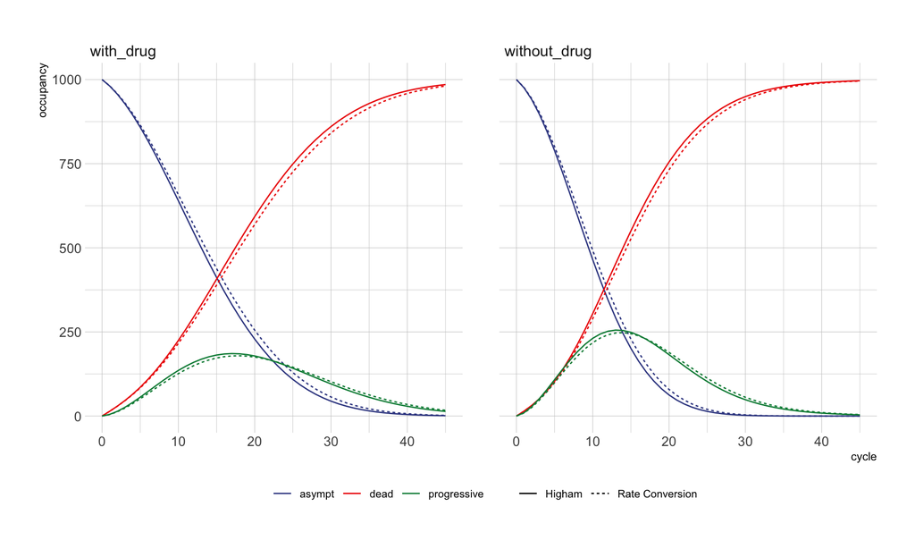

Figure 1: Comparison of State Occupancy Across Embedding Strategy Methods

```r
df_traceA <-
  cbind.data.frame(trace) %>%
  janitor::clean_names(.) %>%
  as_tibble() %>%
  mutate(cycle = row_number()-1) %>%
  gather(measure,occupancy,-cycle) %>%
  separate(measure, into=c("null","state"), sep = "without_drug_|with_drug_",remove = F) %>%
  select(-null) %>%
  mutate(strategy = ifelse(grepl("without_drug",measure),"without_drug","with_drug")) %>%
  mutate(method = "Rate Conversion")

df_traceB <-
  cbind.data.frame(traceB) %>%
  janitor::clean_names(.) %>%
  as_tibble() %>%
  # Must add death states together to make them comparable to strategy A.
  mutate(without_drug_dead = without_drug_dead_cause  + without_drug_dead ) %>%
  mutate(with_drug_dead = with_drug_dead_cause  + with_drug_dead ) %>%
  select(-without_drug_dead_cause,-with_drug_dead_cause) %>%
  mutate(cycle = row_number()-1) %>%
  gather(measure,occupancy,-cycle) %>%
  separate(measure, into=c("null","state"), sep = "without_drug_|with_drug_",remove = F) %>%
  select(-null) %>%
  mutate(strategy = ifelse(grepl("without_drug",measure),"without_drug","with_drug")) %>%
  mutate(method = "Higham")

df_traceA %>%
  bind_rows(df_traceB) %>%
  filter(!grepl("^tr",state)) %>%
  ggplot(aes(x = cycle, y = occupancy, colour = factor(state),lty=factor(method)))  +
  geom_line()  +
  facet_grid(~strategy) +
  theme_ipsum_pub(base_family = "Arial") +
  scale_colour_aaas(name = "") +
  scale_linetype(name="") +
  theme(legend.position = "bottom")
```

# Outcomes

Our final step is to calculate model outcomes such as life expectancy, discounted QALYs and costs, and ICERs.

## Survival

Figure 2 constructs survival curves using a “payoff” of 1 if the individual is alive and 0 otherwise.

Note that the code also normalizes state ocucpancy by the initial cohort size so that survival is expressed in terms of a fraction of the cohort, rather than in terms of a count of indiviudals

```r
survival_payoff = c("Asympt" = 1, "Progressive" = 1, "Dead" = 0 , "trDeadCause" = 0)
survival = lapply(trace,function(tr) ((tr / params$n_cohort)%*% survival_payoff))

survival_payoffB = c("Asympt" = 1, "Progressive" = 1, "DeadCause" = 0, "Dead" = 0 , "trDeadCause" = 0)
survivalB = lapply(traceB,function(tr) ((tr / paramsB$n_cohort)%*% survival_payoffB))
```

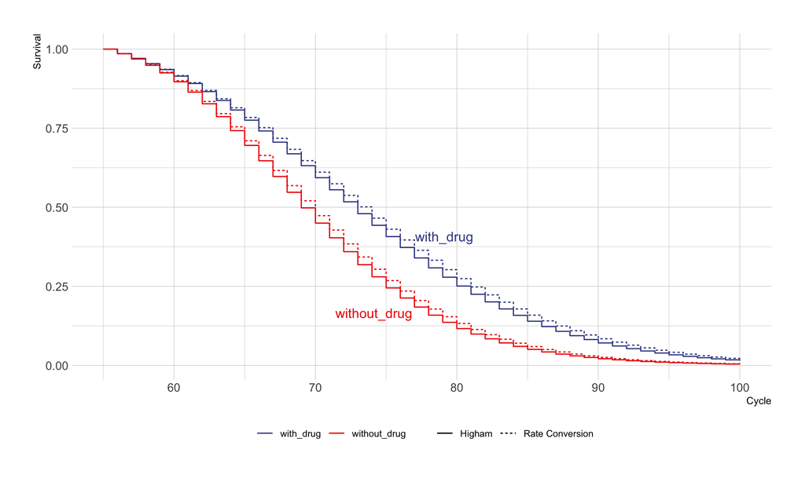

Figure 2: Survival Curves by Strategy and Method

```r
df_surv = data.frame(survival) %>%
    mutate(age = params$initial_age + (row_number()-1)*params$cycle_length) %>%
    tibble() %>%
    gather(strategy, value,-age) %>%
    tibble() %>%
    mutate(method = "Rate Conversion")

df_survB = data.frame(survivalB) %>%
    mutate(age = paramsB$initial_age + (row_number()-1)*paramsB$cycle_length) %>%
    tibble() %>%
    gather(strategy, value,-age) %>%
    tibble() %>%
    mutate(method = "Higham")

df_surv %>%
  bind_rows(df_survB) %>%
    ggplot(aes(x = age, y = value, colour = strategy, lty=method)) + geom_step() +
    hrbrthemes::theme_ipsum_pub(base_family = "Arial") +
    ggsci::scale_colour_aaas(name="") +
    scale_linetype(name = "") +
    directlabels::geom_dl(data = df_surv, method = list("smart.grid"),aes(label = strategy)) +
    theme(legend.position = "bottom") +
    labs(x = "Cycle", y = "Survival")
```

## Life Expectancy

Life expectancy is calculated by summing up the survival curves after applying a cycle correction based on [Simpson’s Rule](https://en.wikipedia.org/wiki/Simpson%27s_rule).

```r
# Rate Conversion Method
(data.frame(lapply(survival,function(x) sum(x*alt_simp_coef(params$n_cycles+1))))*params$cycle_length) %>%
  data.frame() %>%
  mutate(diff = with_drug - without_drug)
```

```
  without_drug with_drug   diff
1       15.383    19.027 3.6441
```

```r
# Higham Method
(data.frame(lapply(survivalB,function(x) sum(x*alt_simp_coef(paramsB$n_cycles+1))))*paramsB$cycle_length) %>%
    data.frame() %>%
  mutate(diff = with_drug - without_drug)
```

```
  without_drug with_drug   diff
1       14.901     18.44 3.5394
```

## Total QALYs and Costs

### Total QALYs

#### Utility Payoffs

- State occupancy in the Asymtomatic state confers a utility accrual of 0.95.
- State occupancy in the Progressive disease state confers a utility of 0.75.

```r
u_payoff = with(params,{
    array(c("Asympt" = uAsymp, "Progressive" = uProg,  "Dead" = 0, "trDeadCause" = 0 ,
            "Asympt" = uAsymp, "Progressive" = uProg,  "Dead" = 0, "trDeadCause" = 0),
          dim = c(1, n_states+1, n_treatments),
          dimnames = list(from = "cost",
                          to = c(s_names,"trDeadCause"),
                          t_names))
}) %>%
    apply(.,3,function(x) x, simplify = FALSE)
u_payoff
```

```
$without_drug
      to
from   Asympt Progressive Dead trDeadCause
  cost   0.95        0.75    0           0

$with_drug
      to
from   Asympt Progressive Dead trDeadCause
  cost   0.95        0.75    0           0
```

#### Total QALYs

```r
total_qalys_cycle =
    map2(trace,u_payoff,~(.x %*% t(.y)))

cycle_adjustments_qalys =
    alt_simp_coef(params$n_cycles + 1) * 1/(1+params$oDr)^(0:(params$n_cycles))

tot_qalys =
    lapply(total_qalys_cycle,function(x) sum(x * cycle_adjustments_qalys * params$cycle_length))
tot_qalys =
    cbind.data.frame(tot_qalys) %>% mutate(inc_qalys = with_drug - without_drug)
tot_qalys
```

```
  without_drug with_drug inc_qalys
1        13654     17195    3541.6
```

#### Cost Payoffs

- For the **No Drug** strategy, tate occupancy in the Asymptomatic state confers a cost of 500 per cycle.
- For the **With Drug** strategy, tate occupancy in the Asymptomatic state confers a cost of 1500 per cycle.
- State occupancy in the Progressive disease state confers a cost of 3000 per cycle.

```r
c_payoff = with(params,{
    cAsymp_ = cAsymp * cycle_length
    cProg_ = cProg * cycle_length
    cDrug_ = cDrug * cycle_length
    array(c("Asympt" = cAsymp_ , "Progressive" = cProg_,  "Dead" = 0, "trDeadCause" =  cDeath,
            "Asympt" = cAsymp_+cDrug_, "Progressive" = cProg_,  "Dead" = 0 , "trDeadCause" = cDeath),
          dim = c(1, n_states+1, n_treatments),
          dimnames = list(from = "cost",
                          to = c(s_names,"trDeadCause"),
                          t_names))
}) %>%
    apply(.,3,function(x) x, simplify = FALSE)
c_payoff
```

```
$without_drug
      to
from   Asympt Progressive Dead trDeadCause
  cost    500        3000    0        1000

$with_drug
      to
from   Asympt Progressive Dead trDeadCause
  cost   1500        3000    0        1000
```

```r
total_costs_cycle = map2(trace,c_payoff,~(.x %*% t(.y)))
cycle_adjustments_costs = alt_simp_coef(params$n_cycles + 1) * 1/(1+params$cDr)^(0:(params$n_cycles))

tot_costs = lapply(total_costs_cycle,function(x) sum(x * cycle_adjustments_costs ))
tot_costs = cbind.data.frame(tot_costs) %>% mutate(inc_costs = with_drug - without_drug)
tot_costs
```

```
  without_drug with_drug inc_costs
1     20476177  35859224  15383047
```

## ICER

```r
tot_costs$inc_costs / tot_qalys$inc_qalys
```

```
[1] 4343.5
```

# DRAFT: Alternative Approach: Eigenvalue Decomposition

This approach will not take the transition probabilities as marginal probabilities, but will use eigenvector decomposition to obtain the rate matrix from the transition probability matrix.

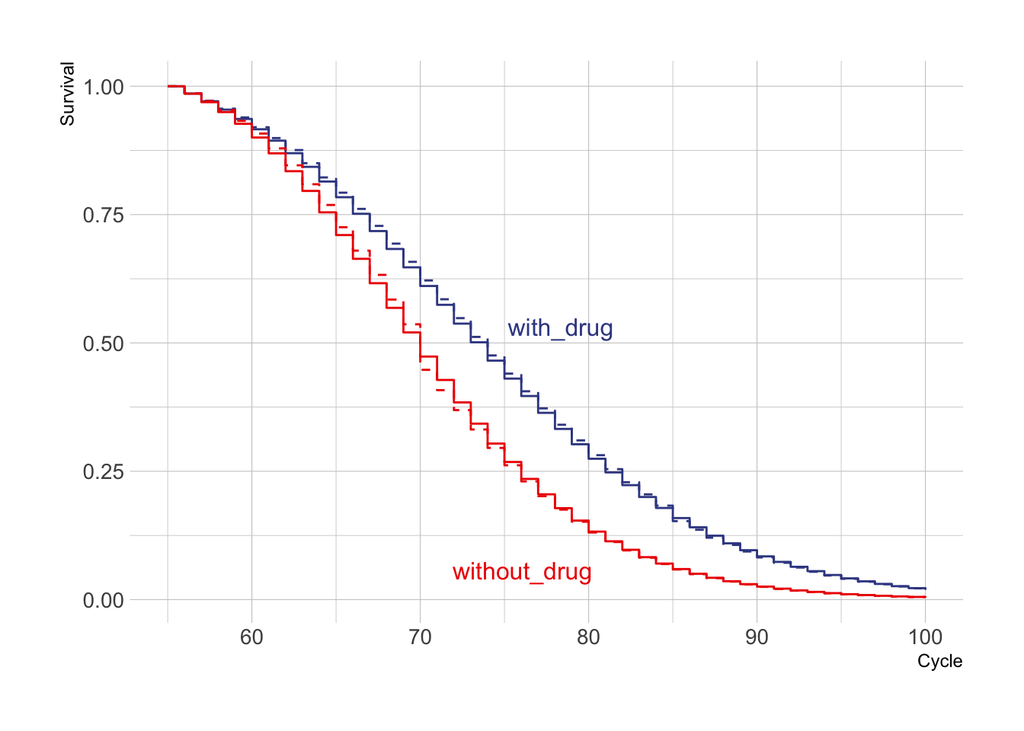

```r
params2 = list(
    t_names = c("without_drug", "with_drug"),      # Treatment names
    n_treatments =2,                               # Number of treatments

    s_names  = c("Asympt", "Progressive", "DeadCause","Dead"), # State names
    n_states = 4,                                  # Number of states

    n_cohort =1000,                                # Cohort size
    cycle_length = params$cycle_length,                              # Cycle length
    time_horizon = 45,                             # Model time horizon (in years)
    initial_age = 55,                              # Cohort starting age
    effect = 0.5,                                  # Treatment Effect (drug)

    cAsymp =500,                                   # Cost of asympomatic state
    cDeath =1000,                                  # cost of death (progressive disease state only)
    cDrug =1000,                                   # Cost of drug
    cProg =3000,                                   # Cycle cost of progressive disease

    uAsymp =0.95,                                  # Asymptomatic state utility
    uProg =0.75,                                   # Progressive disease state utility

    oDr = 0.0,                                    # Discount rate (QALYs)
    cDr = 0.0,                                    # Discount rate (costs)

    tpDcm =0.15,                                   # Death from progressive disease trans prob
    tpProg =0.01,                                  # Transition prob: progressive disease
    tpDn =0.0379                                   # Background mortality transition prob
)

params2 =
    modifyList(params2, with(params2, {
        list(
            n_cycles = time_horizon / cycle_length,
            oDr = ((1 + oDr)^(cycle_length) - 1),
            cDr = ((1 + cDr)^(cycle_length) - 1)
        )
    }))

fn_mRt_eigen =function(t, params) {
    with(params, {
        lapply(t, function(tt) {

            current_age =initial_age + cycle_length * tt
            year = tt * cycle_length

            # Get background mortality rate
            tpDn_lookup <-
                c(
                    "(34,44]" = 0.0017,
                    "(44,54]" = 0.0044,
                    "(54,64]" = 0.0138,
                    "(64,74]" = 0.0379,
                    "(74,84]" = 0.0912,
                    "(84,100]" = 0.1958
                )
            age_grp =cut(current_age - tt * cycle_length, breaks = c(34,44,54,64,74,84,100))
            tpDn =tpDn_lookup[age_grp]

            tpProg_ = tpProg * ceiling(year)

            # Convert supplied probabilities back to rates.
            rProg = tpProg_
            rProgDrug = (tpProg_*(1-effect))
            rDcm = tpDcm
            rDn = tpDn


            mP_ =
                array(data = c(
                    0, 0, 0, 0,
                    rProg, 0, 0, 0,
                    0 ,rDcm, 0, 0,
                    rDn, rDn , 0,0,

                    0, 0, 0, 0,
                    rProgDrug, 0, 0, 0,
                    0 ,rDcm, 0, 0,
                    rDn, rDn , 0,0 ),

                    dim = c(n_states, n_states, n_treatments),
                    dimnames = list(from = s_names,
                                    to = s_names,
                                    t_names))
            mP_ <- apply(mP_,3,simplify = FALSE, function(x) {
                diag(x) = 1 - rowSums(x)
                x
            })

            mR_ <-
                lapply(mP_,function(x) {
                V  = eigen(x)$vectors
                iV = solve(V)
                Ap = iV %*% x %*% V
                lAp = diag(log(diag(Ap)), nrow(Ap), ncol(Ap))
                R  = V %*% lAp %*% iV
                R[abs(R) < 1e-6 ] <- 0
                R
            })



            # Balance out rate matrix
            mR = lapply(mR_,function(x){
                diag(x) = rep(0,nrow(x))
                diag(x) = -rowSums(x)
                dimnames(x) = list(c(s_names),
                                c(s_names))
                x
            })



        })
    })
}

fn_mRt_nonmarkov_eigen = function(R,params) {
    R %>% map(~({
        R_ = .x
        rDcm = -log(1 - params$tpDcm)
        lapply(R_,function(x) {
            x_ = cbind(x,"trDeadCause" = rep(0, params$n_states))
            x_ = rbind(x_,"trDeadCause" = rep(0,params$n_states+1))
            x_["Progressive","trDeadCause"] = rDcm
            x_
        })
    }))
}

params2$mRMarkov <- fn_mRt_eigen(t = 1:params2$n_cycles, params2)
params2$mR = fn_mRt_nonmarkov_eigen(R =params2$mRMarkov,params2)
params2$mP = fn_mP(R = params2$mR, params2)

trace_eigen = # Create the trace given the parameters.
    sim_cohort(params2)

survival_payoff_eigen = c("Asympt" = 1, "Progressive" = 1, "DeadCause" = 0,  "Dead" = 0 , "trDeadCause" = 0)
survival_eigen = lapply(trace_eigen,function(tr) ((tr / params2$n_cohort)%*% survival_payoff_eigen))

df_surv_eigen = data.frame(survival_eigen) %>%
    mutate(age = params2$initial_age + (row_number()-1)*params2$cycle_length) %>%
    tibble() %>%
    gather(strategy, value,-age) %>%
    tibble()
df_surv %>%
    ggplot(aes(x = age, y = value, colour = strategy)) + geom_step() +
    hrbrthemes::theme_ipsum_pub(base_family = "Arial") +
    ggsci::scale_colour_aaas() +
    directlabels::geom_dl(method = list("smart.grid"),aes(label = strategy)) +
    theme(legend.position = "none") +
    labs(x = "Cycle", y = "Survival") +
    geom_step(data = df_surv_eigen, lty = 2)
```

```r
u_payoff2 = with(params2,{
    array(c("Asympt" = uAsymp, "Progressive" = uProg,  "DeadCause" = 0, "Dead" = 0, "trDeadCause" = 0 ,
            "Asympt" = uAsymp, "Progressive" = uProg,  "DeadCause" = 0, "Dead" = 0, "trDeadCause" = 0),
          dim = c(1, n_states+1, n_treatments),
          dimnames = list(from = "cost",
                          to = c(s_names,"trDeadCause"),
                          t_names))
}) %>%
    apply(.,3,function(x) x, simplify = FALSE)

c_payoff2 = with(params2,{
    cAsymp_ = cAsymp * cycle_length
    cProg_ = cProg * cycle_length
    cDrug_ = cDrug * cycle_length
    array(c("Asympt" = cAsymp_ , "Progressive" = cProg_,  "DeadCause" = 0, "Dead" = 0, "trDeadCause" =  cDeath,
            "Asympt" = cAsymp_+cDrug_, "Progressive" = cProg_,  "DeadCause" = 0,"Dead" = 0 , "trDeadCause" = cDeath),
          dim = c(1, n_states+1, n_treatments),
          dimnames = list(from = "cost",
                          to = c(s_names,"trDeadCause"),
                          t_names))
}) %>%
    apply(.,3,function(x) x, simplify = FALSE)

total_qalys_cycle2 =
    map2(trace_eigen,u_payoff2,~(.x %*% t(.y)))

cycle_adjustments_qalys2 =
    alt_simp_coef(params2$n_cycles + 1) * 1/(1+params2$oDr)^(0:(params2$n_cycles))

tot_qalys2 =
    lapply(total_qalys_cycle2,function(x) sum(x * cycle_adjustments_qalys2 * params2$cycle_length))
tot_qalys2 =
    cbind.data.frame(tot_qalys2) %>% mutate(inc_qalys = with_drug - without_drug)
tot_qalys2
```

```
  without_drug with_drug inc_qalys
1        13666     17312    3646.1
```

```r
total_costs_cycle2 = map2(trace_eigen,c_payoff2,~(.x %*% t(.y)))
cycle_adjustments_costs2 = alt_simp_coef(params2$n_cycles + 1) * 1/(1+params2$cDr)^(0:(params2$n_cycles))

tot_costs2 = lapply(total_costs_cycle2,function(x) sum(x * cycle_adjustments_costs2 ))
tot_costs2 = cbind.data.frame(tot_costs2) %>% mutate(inc_costs = with_drug - without_drug)
tot_costs2
```

```
  without_drug with_drug inc_costs
1     20763762  36577346  15813584
```

```r
tot_costs2$inc_costs / tot_qalys2$inc_qalys
```

```
[1] 4337.2
```

## References

Green, Nathan, Felicity Lamrock, Nichola Naylor, Jack Williams, and Andrew Briggs. 2023. “Health Economic Evaluation Using Markov Models in r for Microsoft Excel Users: A Tutorial.” *PharmacoEconomics* 41 (1): 5–19.

Higham, Nicholas J. 2008. *Functions of Matrices: Theory and Computation*. SIAM.